# Data_image

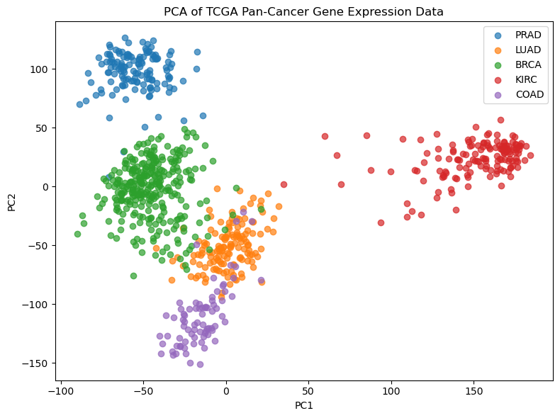

```python
import pandas as pd
from sklearn.decomposition import PCA
import matplotlib.pyplot as plt

# Load data
X = pd.read_csv('data/TCGA-PANCAN-HiSeq-801x20531/data.csv', index_col=0)
y = pd.read_csv('Data/TCGA-PANCAN-HiSeq-801x20531/labels.csv', index_col=0).squeeze()

# PCA
pca = PCA(n_components=2)
X_pca = pca.fit_transform(X)

# Plot
plt.figure(figsize=(8,6))
for subtype in y.unique():
    idx = y == subtype
    plt.scatter(X_pca[idx, 0], X_pca[idx, 1], label=subtype, alpha=0.7)
plt.xlabel('PC1')
plt.ylabel('PC2')
plt.title('PCA of TCGA Pan-Cancer Gene Expression Data')
plt.legend()
plt.tight_layout()
plt.show()
```

This code helps you visualize complex cancer gene expression data by making it easier to see patterns or groups (called “subtypes”) among different cancer samples. Here’s how: 1. Loading the Data Gene Expression Data: Think of this as a big spreadsheet where each row is a patient’s cancer sample, and each column is the activity (expression) of a different gene. Labels: Another spreadsheet that tells you what type of cancer each sample is (the “subtype”). 2. PCA (Principal Component Analysis) What is PCA? Imagine you have a huge table with thousands of columns (genes). PCA is a mathematical trick that reduces all those columns down to just 2, while keeping as much important information as possible. Why do this? With just 2 columns, you can make a simple 2D plot (like a scatter plot), which is much easier to look at and understand. 3. Making the Plot Each dot: Represents a single cancer sample (patient). Color of dot: Shows which cancer subtype that sample belongs to. Clusters: If you see groups of the same color, it means those subtypes have similar gene expression patterns. Why Is This Useful? Big Picture: Scientists use this kind of plot to quickly see if different types of cancer are really different at the gene level. For Presentations: This plot is a great way to show that you’re using real data and powerful tools to analyze it! In Short You have lots of data. You use PCA to make it simple. You plot it to see patterns. You use the plot to explain your findings.